# Интегралы и площадь под графиком

Презентация

# Интегралы и площадь под графиком

## Слайд 1: Введение

Тема: Интегралы и площадь под графиком

Цель: Понять, что такое интегралы, как они связаны с площадью и как они используются в реальной жизни.

## Слайд 2: Что такое интеграл?

Определение: Интеграл — это математическая операция, которая позволяет находить площадь под кривой на графике функции.

Пример: Представьте, что у вас есть график скорости автомобиля по времени, и вы хотите узнать, сколько пути он проехал за определённый промежуток времени. Интеграл позволяет это вычислить.

## Слайд 3: Основные понятия

Функция: Это математическое правило, которое задаёт зависимость между переменными. Например, $y = f(x)$.

Площадь под графиком: Это площадь, заключённая между графиком функции и осью $x$ на отрезке от $a$ до $b$.

## Слайд 4: Формулы

Определённый интеграл:

$$\int_{a}^{b} f(x) \, dx$$

Это обозначение для нахождения площади под графиком функции $f(x)$ на отрезке от $a$ до $b$.

Интеграл позволяет найти площадь даже под кривыми, которые не являются прямыми.

Основная теорема анализа:

$$\int_{a}^{b} f(x) \, dx = F(b) - F(a)$$

$F(x)$ — это первообразная функции $f(x)$, то есть функция, производная которой равна $f(x)$.

## Слайд 5: Практическое применение интегралов

Физика: Для нахождения работы, выполненной силой, используя график силы по времени.

Экономика: Для нахождения общей прибыли или затрат за определённый период времени.

Медицина: Для расчёта объёмов крови или других жидкостей, которые текут через артерии.

## Слайд 6: Пример из реальной жизни

Пример: Представьте, что вы хотите узнать, сколько топлива потребляет автомобиль на определённом маршруте. График расхода топлива по времени будет функцией, и интеграл этой функции по времени даст общий расход топлива.

## Слайд 7: Пример реализации на Python

```
Пройденное расстояние: 155.00000000000003 единиц
```

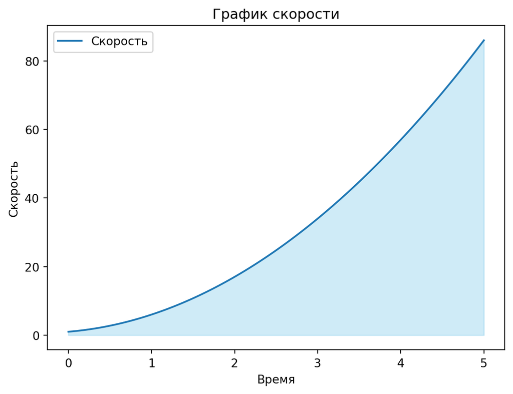

```python
import numpy as np
import scipy.integrate as integrate
import matplotlib.pyplot as plt

# Функция, для которой будем вычислять интеграл
def speed(t):
    return 3 * t**2 + 2 * t + 1  # Пример функции скорости

# Интервал времени
a = 0  # Начало
b = 5  # Конец

# Вычисление интеграла
result, error = integrate.quad(speed, a, b)

print(f"Пройденное расстояние: {result} единиц")

# Визуализация графика функции
t = np.linspace(a, b, 100)
y = speed(t)
plt.plot(t, y, label="Скорость")
plt.fill_between(t, y, color="skyblue", alpha=0.4)
plt.title("График скорости")
plt.xlabel("Время")
plt.ylabel("Скорость")
plt.legend()
plt.show()
```

В этом примере мы вычисляем, какое расстояние прошёл автомобиль, если его скорость задана функцией $3t^2 + 2t + 1$.

## Слайд 8: Заключение

Интегралы — это мощный инструмент для нахождения площадей, объёмов, работы и других важных величин.

Они находят широкое применение в различных областях науки и техники.